# Home Credit Default Risk - Exploratory Data Analysis

Author

Ian Christiansen

Published

January 30, 2026

## Business Problem

The goal of this project is to predict the likelihood that a Home Credit loan applicant will default on their loan. Accurate default prediction is critical for balancing financial risk with access to credit, particularly for applicants with limited or non-traditional credit histories. This exploratory data analysis focuses on understanding the structure and quality of the application and transactional data, identifying patterns associated with default risk, and highlighting potential challenges that may affect downstream modeling decisions.

## Data Sources

This analysis uses data from the Home Credit Default Risk project. The primary datasets include the application training and test files, which contain applicant-level demographic, financial, and credit history variables. Additional supplementary datasets provide transactional and historical credit information that can be aggregated and joined to the application data to enrich predictive features.

## Setup

This section loads the R packages used throughout the notebook and sets global options to ensure clean, readable output during exploratory analysis.

```r
#Load libraries
library(tidyverse)
library(janitor)
library(skimr)
library(naniar)
library(scales)

#Make printing a little cleaner
options(scipen = 999)
```

## Load and Inspect Application Data

In this section, I load the application train/test datasets, clean column names, and review dimensions + variable types to understand the data structure before deeper EDA.

```r
#Load the application training and test datasets
#Clean column names to make them easier to work with
app_train <- read_csv("application_train.csv", show_col_types = FALSE) |>
  clean_names()

app_test <- read_csv("application_test.csv", show_col_types = FALSE) |>
  clean_names()

#Check the number of rows and columns in each dataset
dim(app_train)
```

```
[1] 307511    122
```

```r
dim(app_test)
```

```
[1] 48744   121
```

```r
#Confirm that the target variable exists only in the training data
"target" %in% names(app_train)
```

```
[1] TRUE
```

```r
"target" %in% names(app_test)
```

```
[1] FALSE
```

```r
#Take a quick look at variable types and example values
glimpse(app_train)
```

```
Rows: 307,511
Columns: 122
$ sk_id_curr                   <dbl> 100002, 100003, 100004, 100006, 100007, 1…
$ target                       <dbl> 1, 0, 0, 0, 0, 0, 0, 0, 0, 0, 0, 0, 0, 0,…
$ name_contract_type           <chr> "Cash loans", "Cash loans", "Revolving lo…
$ code_gender                  <chr> "M", "F", "M", "F", "M", "M", "F", "M", "…
$ flag_own_car                 <chr> "N", "N", "Y", "N", "N", "N", "Y", "Y", "…
$ flag_own_realty              <chr> "Y", "N", "Y", "Y", "Y", "Y", "Y", "Y", "…
$ cnt_children                 <dbl> 0, 0, 0, 0, 0, 0, 1, 0, 0, 0, 1, 0, 0, 1,…
$ amt_income_total             <dbl> 202500.00, 270000.00, 67500.00, 135000.00…
$ amt_credit                   <dbl> 406597.5, 1293502.5, 135000.0, 312682.5, …
$ amt_annuity                  <dbl> 24700.5, 35698.5, 6750.0, 29686.5, 21865.…
$ amt_goods_price              <dbl> 351000, 1129500, 135000, 297000, 513000, …
$ name_type_suite              <chr> "Unaccompanied", "Family", "Unaccompanied…
$ name_income_type             <chr> "Working", "State servant", "Working", "W…
```

[output cut: 109 more lines]

The training dataset contains one additional column, target, which indicates whether an applicant defaulted on their loan. This column is not included in the test dataset.

## Target Variable: Class Balance and Baseline Accuracy

In this section, I examine the distribution of the target variable to understand class balance and calculate a simple baseline accuracy. This helps set expectations for how difficult the prediction task is and provides a reference point for evaluating future models.

```r
#Examine the distribution of the target variable
target_counts <- app_train |>
  count(target) |>
  mutate(percent = n / sum(n))

target_counts
```

```
# A tibble: 2 × 3
  target      n percent
   <dbl>  <int>   <dbl>
1      0 282686  0.919
2      1  24825  0.0807
```

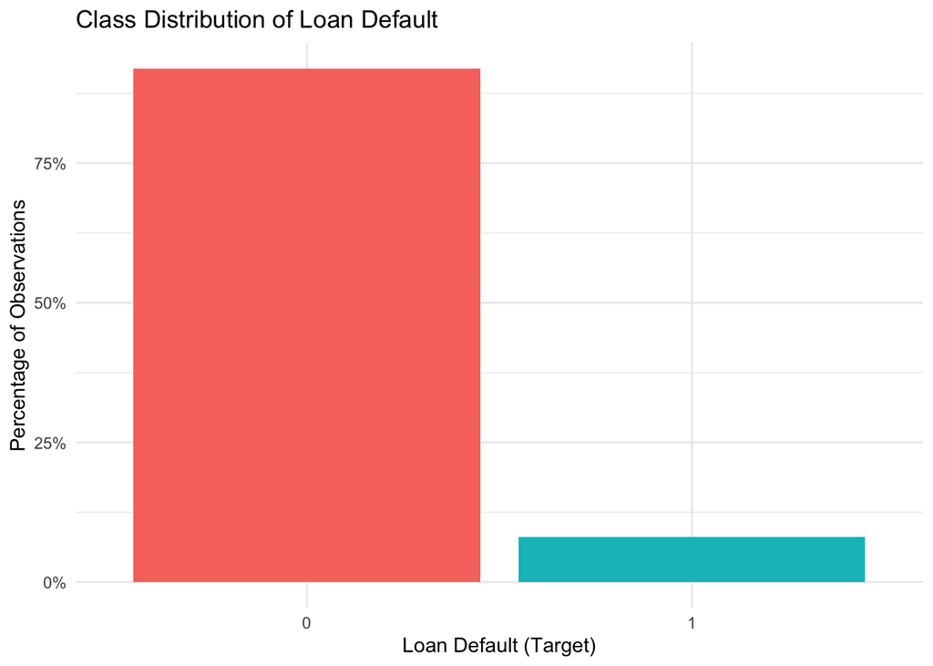

```r
#Visualize class balance
ggplot(target_counts, aes(x = factor(target), y = percent, fill = factor(target))) +
  geom_col() +
  scale_y_continuous(labels = scales::percent_format()) +
  labs(
    x = "Loan Default (Target)",
    y = "Percentage of Observations",
    title = "Class Distribution of Loan Default"
  ) +
  theme_minimal() +
  theme(legend.position = "none")
```

```r
#Calculate baseline accuracy (predicting the majority class)
baseline_accuracy <- max(target_counts$percent)
baseline_accuracy
```

```
[1] 0.9192712
```

The target variable is highly imbalanced, with about 92% of observations representing non-default loans. Because of this, a simple model that always predicts “no default” would already achieve a baseline accuracy of around 92%. This shows that accuracy alone is not very informative for this problem and that other evaluation metrics will be important when building models.

## Missing Data: Scope and Proposed Handling

In this section, I examine the extent of missing data across variables in the application training dataset. Understanding the scope and pattern of missingness is important for identifying potential data quality issues and informing decisions about feature engineering, imputation, or variable removal in later modeling steps.

```r
#Examine overall missingness by variable (excluding the target)
missing_summary <- app_train |>
  select(-target) |>
  summarise(across(everything(), ~ mean(is.na(.)))) |>
  pivot_longer(
    cols = everything(),
    names_to = "variable",
    values_to = "missing_rate"
  ) |>
  arrange(desc(missing_rate))

#View the variables with the highest missing rates
head(missing_summary, 10)
```

```
# A tibble: 10 × 2
   variable                 missing_rate
   <chr>                           <dbl>
 1 commonarea_avg                  0.699
 2 commonarea_mode                 0.699
 3 commonarea_medi                 0.699
 4 nonlivingapartments_avg         0.694
 5 nonlivingapartments_mode        0.694
 6 nonlivingapartments_medi        0.694
 7 fondkapremont_mode              0.684
 8 livingapartments_avg            0.684
 9 livingapartments_mode           0.684
10 livingapartments_medi           0.684
```

```r
#Count how many variables have any missing values
sum(missing_summary$missing_rate > 0)
```

```
[1] 67
```

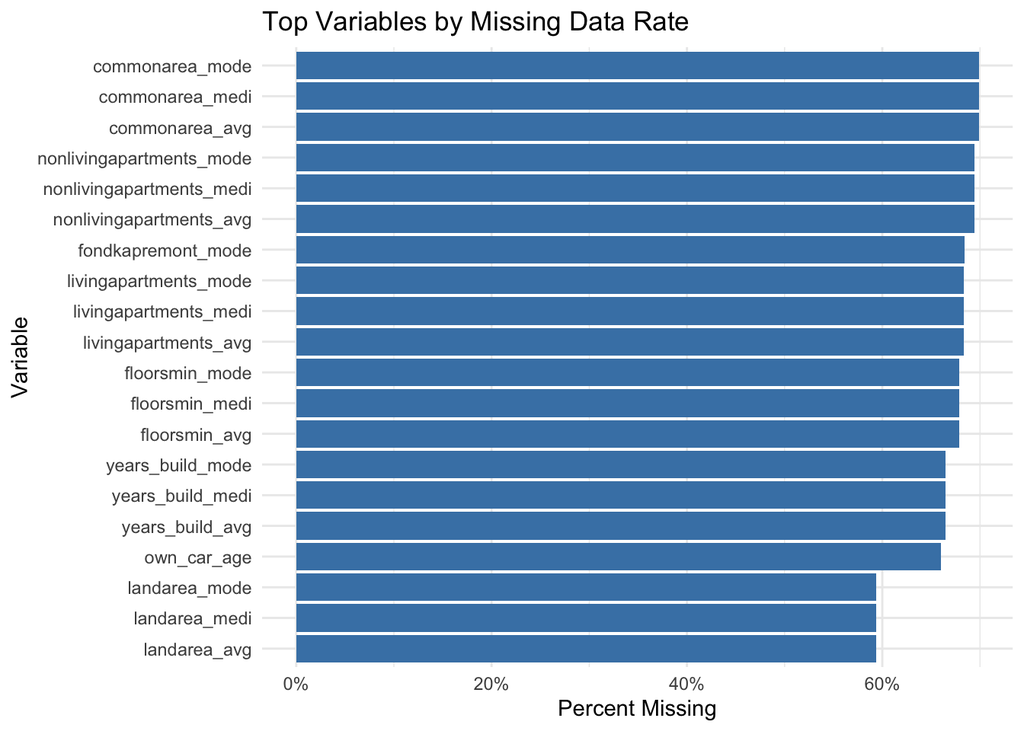

```r
#Visualize missingness for the most incomplete variables
missing_summary |>
  slice_max(missing_rate, n = 20) |>
  ggplot(aes(x = reorder(variable, missing_rate), y = missing_rate)) +
  geom_col(fill = "steelblue") +
  coord_flip() +
  scale_y_continuous(labels = scales::percent_format()) +
  labs(
    x = "Variable",
    y = "Percent Missing",
    title = "Top Variables by Missing Data Rate"
  ) +
  theme_minimal()
```

The plot shows that many variables have high levels of missing data, with several features missing values for over 60% of observations. These variables are mostly related to property characteristics, suggesting that this information is not available for all applicants. Because the missingness is substantial, these features will need careful handling in later modeling steps, such as imputation, using missing indicators, or possibly removing them if they add limited value.

## Predictor Relationships: What Looks Predictive?

In this section, I examine how selected predictor variables relate to the target variable (loan default). By comparing distributions and default rates across groups, I identify features that appear to differ meaningfully between default and non-default loans.

# Numeric Predictors vs. Default Status

I begin by comparing several numeric predictors across default and non-default loans. These variables were chosen because they have relatively lower missingness and clear financial or demographic relevance. # Compare numeric predictors by default status

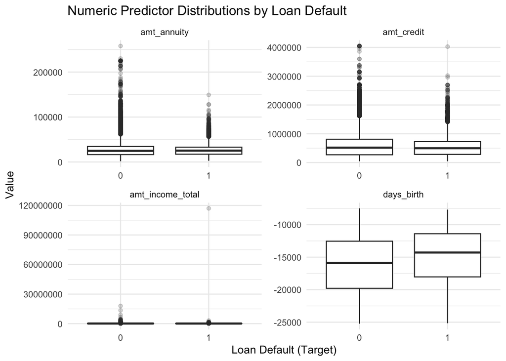

```r
#Select a few numeric variables that are important and have lower missingness
numeric_vars <- c("amt_income_total", "amt_credit", "amt_annuity", "days_birth")

#Reshape the data so each numeric variable can be plotted separately
#and compare values across default (1) vs non-default (0) loans
app_train |>
  select(all_of(numeric_vars), target) |>
  pivot_longer(
    cols = -target,
    names_to = "variable",
    values_to = "value"
  ) |>

  #Create boxplots to compare distributions by default status
  ggplot(aes(x = factor(target), y = value)) +

  #Use boxplots to show medians, spread, and outliers
  geom_boxplot(outlier.alpha = 0.2) +

  #Separate each numeric variable into its own panel
  facet_wrap(~ variable, scales = "free") +

  #Label axes and add a clear title
  labs(
    x = "Loan Default (Target)",
    y = "Value",
    title = "Numeric Predictor Distributions by Loan Default"
  ) +

  #Use a clean theme to make the plot easier to read
  theme_minimal()
```

The numeric predictors show some clear differences between default and non-default loans, although there is still a lot of overlap between the two groups. Defaulted loans tend to be associated with lower total income, smaller credit amounts, and slightly lower annuity payments. The days_birth variable also suggests that borrowers who default are generally younger on average. While none of these variables alone strongly separates defaults from non-defaults, the consistent shifts in their distributions indicate that they are likely informative and could help improve model performance when used together.

# Categorical Predictors and Default Rates

Next, I examined categorical variables by calculating default rates within each category.

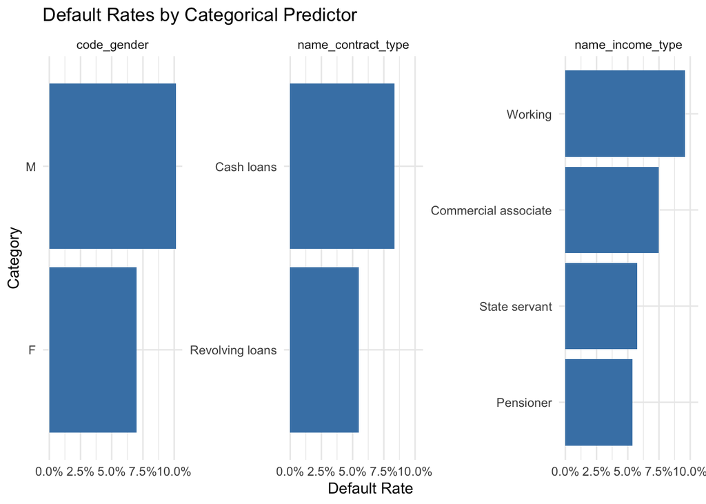

```r
#Default rates for selected categorical predictors
#These variables are chosen because they are common, interpretable,
#and likely related to loan risk
categorical_vars <- c("name_contract_type", "code_gender", "name_income_type")

app_train |>
  #Keep only the categorical predictors and the target
  select(all_of(categorical_vars), target) |>

  #Convert data to long format so categories can be analyzed consistently
  pivot_longer(
    cols = -target,
    names_to = "variable",
    values_to = "category"
  ) |>

  #Group by each variable and category to compute default rates
  group_by(variable, category) |>
  summarise(
    default_rate = mean(target),  #proportion of defaults in each category
    n = n(),                       #number of observations in each group
    .groups = "drop"
  ) |>

  #Filter out very small groups to avoid noisy or unreliable rates
  filter(n > 1000) |>

  #Create bar charts of default rates by category
  ggplot(aes(x = reorder(category, default_rate), y = default_rate)) +

  #Use bars to show average default rate for each category
  geom_col(fill = "steelblue") +

  #Flip coordinates so category labels are easier to read
  coord_flip() +

  #Separate plots by predictor since scales differ
  facet_wrap(~ variable, scales = "free_y") +

  #Format y-axis as percentages
  scale_y_continuous(labels = scales::percent_format()) +

  #Add clear labels and title
  labs(
    x = "Category",
    y = "Default Rate",
    title = "Default Rates by Categorical Predictor"
  ) +

  #Keep the plot clean and simple
  theme_minimal()
```

The plots show noticeable differences in default rates across several categorical variables. Cash loans have higher default rates than revolving loans, which suggests loan type matters. Males also appear to default slightly more often than females. Looking at income type, working applicants have the highest default rates, while pensioners and state servants tend to default less. Overall, these differences suggest that categorical predictors contain useful information and could help explain default behavior in later models.

## Data Quality Checks and Potential Issues

In this section, I perform basic data quality checks to identify potential issues that could impact modeling performance. This includes checking for duplicate rows, unrealistic or invalid values, and variables with extreme skewness or outliers. Identifying these issues early helps guide decisions around data cleaning, transformations, and feature handling in later steps.

```r
#Check for duplicate rows
n_duplicates <- nrow(app_train) - nrow(distinct(app_train))
n_duplicates
```

```
[1] 0
```

```r
#Check for invalid or unrealistic values in key numeric variables
app_train |>
  summarise(
    negative_income = sum(amt_income_total < 0, na.rm = TRUE),
    negative_credit = sum(amt_credit < 0, na.rm = TRUE),
    negative_annuity = sum(amt_annuity < 0, na.rm = TRUE)
  )
```

```
# A tibble: 1 × 3
  negative_income negative_credit negative_annuity
            <int>           <int>            <int>
1               0               0                0
```

```r
#Check age variable (days_birth should be negative)
summary(app_train$days_birth)
```

```
   Min. 1st Qu.  Median    Mean 3rd Qu.    Max.
 -25229  -19682  -15750  -16037  -12413   -7489
```

```r
#Identify variables with extreme skewness using quantiles
app_train |>
  select(amt_income_total, amt_credit, amt_annuity) |>
  summarise(across(
    everything(),
    list(
      p50 = ~ quantile(.x, 0.50, na.rm = TRUE),
      p95 = ~ quantile(.x, 0.95, na.rm = TRUE),
      p99 = ~ quantile(.x, 0.99, na.rm = TRUE)
    )
  ))
```

```
# A tibble: 1 × 9
  amt_income_total_p50 amt_income_total_p95 amt_income_total_p99 amt_credit_p50
                 <dbl>                <dbl>                <dbl>          <dbl>
1               147150               337500               472500         513531
# ℹ 5 more variables: amt_credit_p95 <dbl>, amt_credit_p99 <dbl>,
#   amt_annuity_p50 <dbl>, amt_annuity_p95 <dbl>, amt_annuity_p99 <dbl>
```

Overall, the data quality checks did not reveal any major problems. There are no duplicate rows in the training data, and the key numeric variables such as income, credit amount, and annuity do not contain invalid negative values. The days_birth variable also looks reasonable, with all values being negative as expected. One thing that does stand out is that several financial variables are heavily right-skewed, with very large values in the upper percentiles. This suggests that outliers could influence some models and may need to be handled through transformations or modeling choices later on.

## Transformation Considerations for Modeling

Based on what I’ve seen so far, a few transformations will likely be helpful before modeling. Several numeric variables, such as amt_income_total, amt_credit, and amt_annuity, are very right-skewed and include some extreme values, so applying a log transformation could make their distributions more manageable. The days_birth variable is recorded as a negative number of days, so converting it to age in years would make it easier to interpret. Some categorical variables also have many categories, and grouping smaller or rare categories may help simplify the model. Finally, since the target variable is highly imbalanced, relying on accuracy alone would be misleading, so alternative metrics and modeling strategies should be considered.

## Supplementary Data: Join Strategy and Aggregation

In addition to the main application data, the Home Credit dataset includes several supplementary tables that provide more detailed historical and transactional information about applicants and are linked using the applicant ID (SK_ID_CURR). These tables often contain multiple rows per applicant, so they cannot be joined directly to the application data without first being aggregated. To address this, the supplementary data would be summarized to the applicant level using measures such as counts, averages, or maximum values that capture past credit behavior. Once aggregated, the resulting features can be merged into the training dataset using a left join, ensuring that all applicants remain in the dataset while adding additional information where available. Any missing values introduced by this process would be handled during later preprocessing or modeling steps.

```r
# Example: aggregating supplementary bureau-style (credit history) data
# This chunk uses a small mock dataset so the notebook runs without
# needing the full supplementary CSV files.
# The goal is to demonstrate the intended aggregation and join strategy.

library(dplyr)
library(tibble)

# Identify the applicant ID column in the main application data
# Home Credit typically uses SK_ID_CURR, but this keeps things flexible
id_col <- names(app_train)[grepl("SK_ID", names(app_train), ignore.case = TRUE)][1]

# If no ID column is detected, default to the standard Home Credit ID
if (is.na(id_col)) {
  id_col <- "SK_ID_CURR"
}

# Create a small mock bureau dataset to illustrate structure
# In the real dataset, each applicant can appear multiple times
set.seed(123)
bureau <- tibble(
  SK_ID_CURR = sample(app_train[[id_col]], 5000, replace = TRUE),
  DAYS_CREDIT = sample(-4000:-30, 5000, replace = TRUE),
  AMT_CREDIT_SUM = runif(5000, 1e4, 1e6)
)

# Aggregate bureau data so there is one row per applicant
# These summaries capture overall historical credit behavior
bureau_agg <- bureau |>
  group_by(SK_ID_CURR) |>
  summarise(
    bureau_records = n(),
    avg_credit_days = mean(DAYS_CREDIT),
    max_credit_amt = max(AMT_CREDIT_SUM),
    .groups = "drop"
  )

# Join the aggregated bureau features back to the main training data
# A left join ensures all applicants remain in the dataset
app_train_enriched <- app_train |>
  left_join(bureau_agg, by = setNames("SK_ID_CURR", id_col))

# Quick check to confirm the new bureau features were added
glimpse(app_train_enriched)
```

```
Rows: 307,511
Columns: 125
$ sk_id_curr                   <dbl> 100002, 100003, 100004, 100006, 100007, 1…
$ target                       <dbl> 1, 0, 0, 0, 0, 0, 0, 0, 0, 0, 0, 0, 0, 0,…
$ name_contract_type           <chr> "Cash loans", "Cash loans", "Revolving lo…
$ code_gender                  <chr> "M", "F", "M", "F", "M", "M", "F", "M", "…
$ flag_own_car                 <chr> "N", "N", "Y", "N", "N", "N", "Y", "Y", "…
$ flag_own_realty              <chr> "Y", "N", "Y", "Y", "Y", "Y", "Y", "Y", "…
$ cnt_children                 <dbl> 0, 0, 0, 0, 0, 0, 1, 0, 0, 0, 1, 0, 0, 1,…
$ amt_income_total             <dbl> 202500.00, 270000.00, 67500.00, 135000.00…
$ amt_credit                   <dbl> 406597.5, 1293502.5, 135000.0, 312682.5, …
$ amt_annuity                  <dbl> 24700.5, 35698.5, 6750.0, 29686.5, 21865.…
$ amt_goods_price              <dbl> 351000, 1129500, 135000, 297000, 513000, …
$ name_type_suite              <chr> "Unaccompanied", "Family", "Unaccompanied…
$ name_income_type             <chr> "Working", "State servant", "Working", "W…
```

[output cut: 112 more lines]

## Results Summary

This exploratory data analysis looked at the Home Credit Default Risk dataset to better understand the data before building any models. The target variable is highly imbalanced, which shows that using accuracy alone would not be very informative. Several numeric variables, such as income, credit amount, annuity, and age, show differences between default and non default applicants, and some categorical variables like loan type and income type also have noticeable differences in default rates. The analysis also showed that many variables have a large amount of missing data, especially property related features, and that several financial variables are highly right skewed. Overall, this EDA helped identify which features may be useful for modeling and highlighted important preprocessing steps, such as handling missing values and skewed variables, that will be important moving forward.

## AI Usage Reflection

I used AI as a helpful tool throughout this EDA to make the analysis process more manageable and efficient. I mainly used it to help write and debug R code for exploring the target variable, visualizing relationships between predictors and default status, examining missing data, and thinking through join and aggregation strategies for the supplementary datasets. I also used AI to help clean up and clarify some of my written explanations after I had already written them myself. Overall, AI was helpful for saving time and working through implementation details, while still allowing me to focus on understanding the data and making my own analytical decisions.